# SuperBowlAds

Mike Wehinger

03/03/2021

## Super Bowl Ad Analysis

This data comes from [FiveThirtyEight](https://github.com/fivethirtyeight/superbowl-ads) where they classified 233 ads from 10 brands that aired the most spots in all 21 Super Bowls this century using seven specific criteria.

This analysis will use that data to see what strategies were used by year and/or brand considering youtube views

### Visualizations

Lets try a Mosaic plot where the bar width is determined by youtube Views and the height is a 100% stacked bar showing proportion of strategies used…

```
## [1] "Mosaic By Year"
```

[figure not shown]

```
## [1] "Mosaic for 2019 & 2020"
```

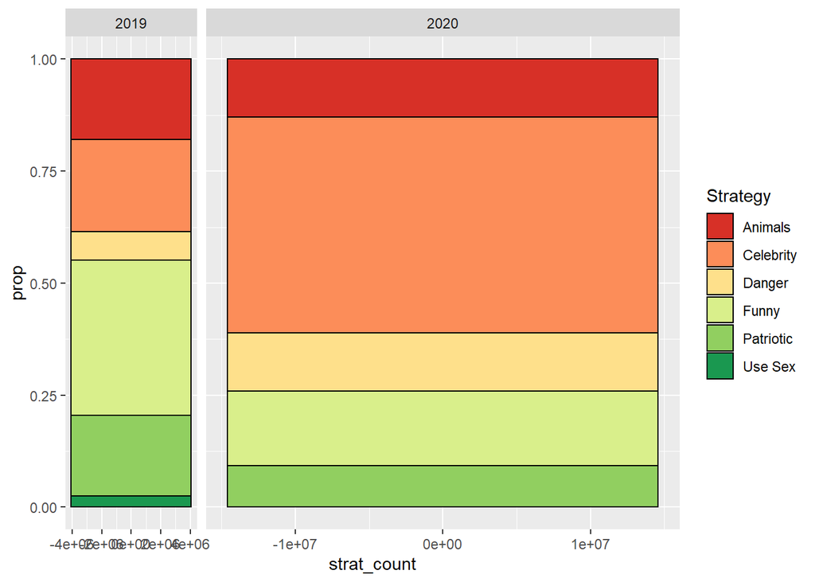

```
## [1] "Mosaic By Brand"
```

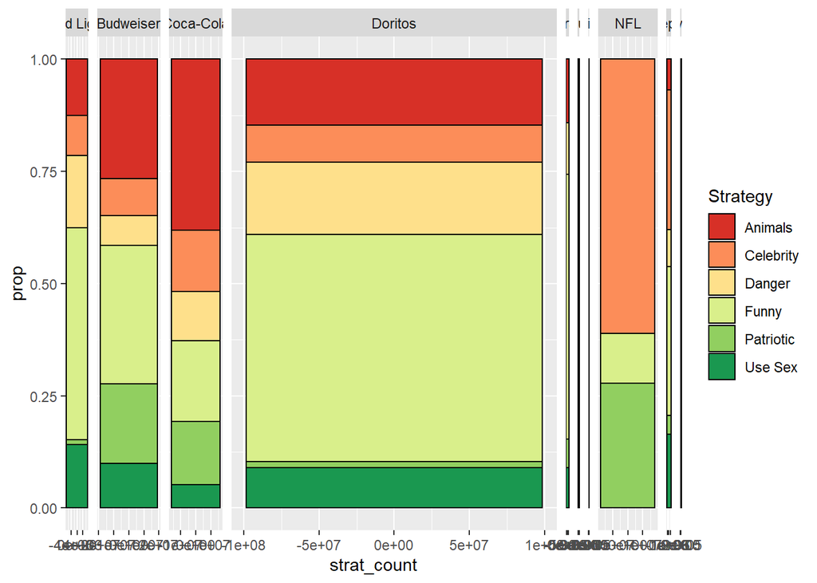

```
## [1] "Mosaic By Year for Budweiser"
```

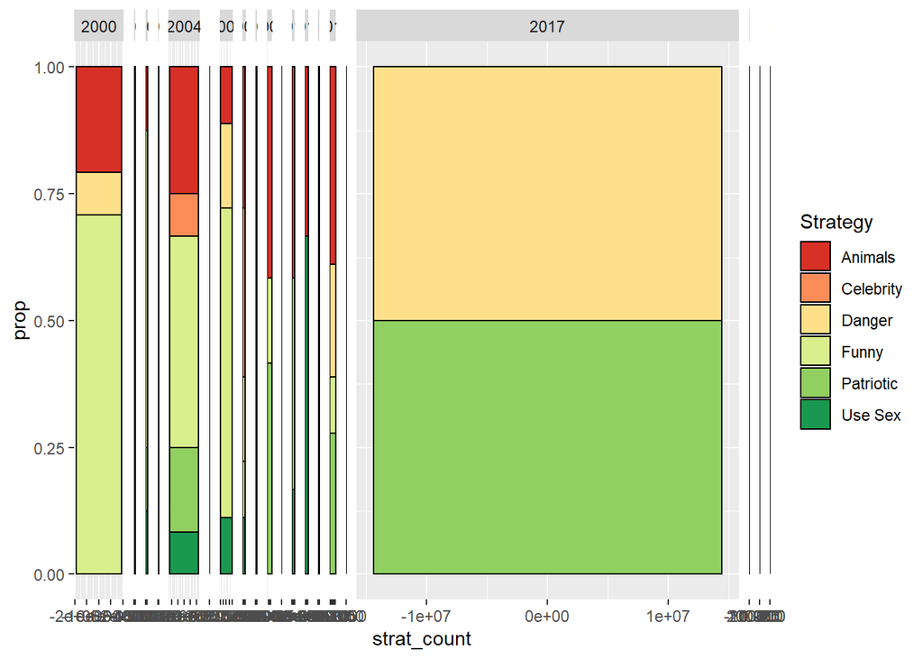

```
## [1] "Mosaic By Brand for 2020"
```

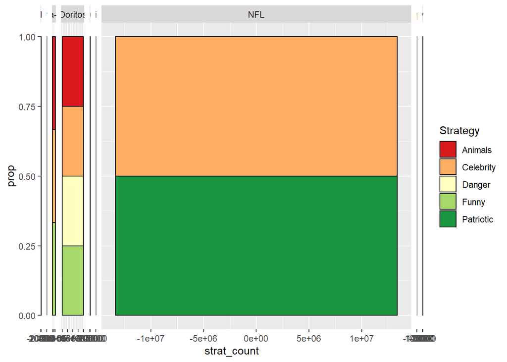

```
## [1] "Mosaic By Year and Brand (excluding Doritos)"
```

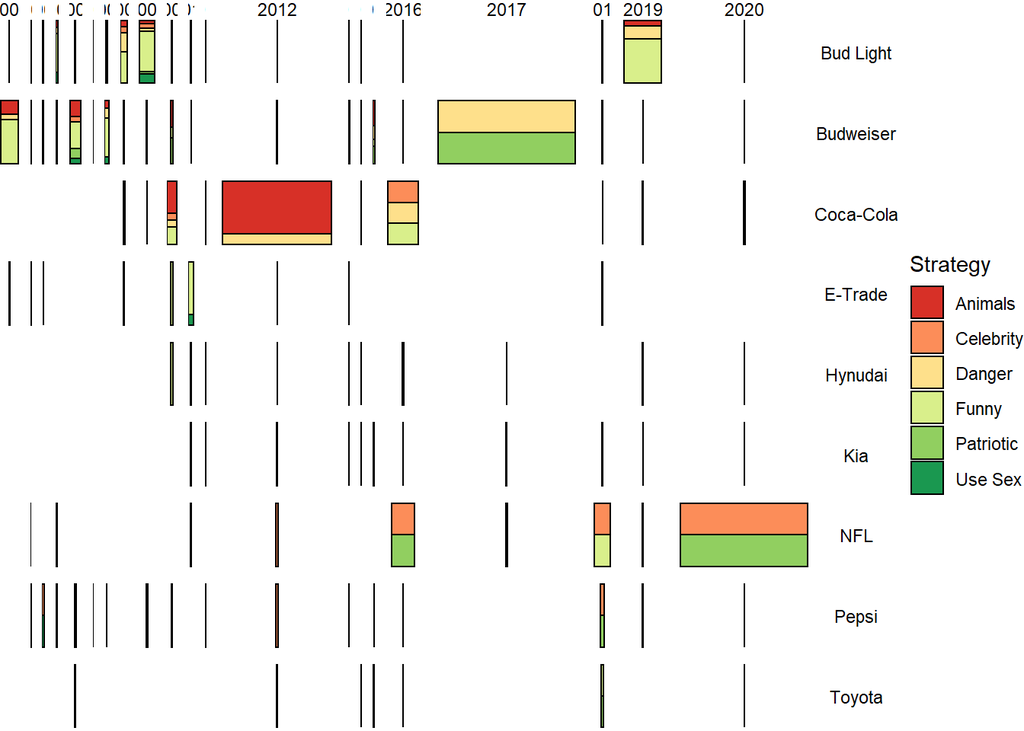

Having the youtube view count on the x-axis is distorting the viz too much. Try moving it to the Y axis, which suggests each strategy is responsible for a certain proportion of views. The x-axis can be add count, which is usually 8 to 12

```
## [1] "Mosaic By Year"
```

[figure not shown]

```
## [1] "Mosaic By Brand"
```

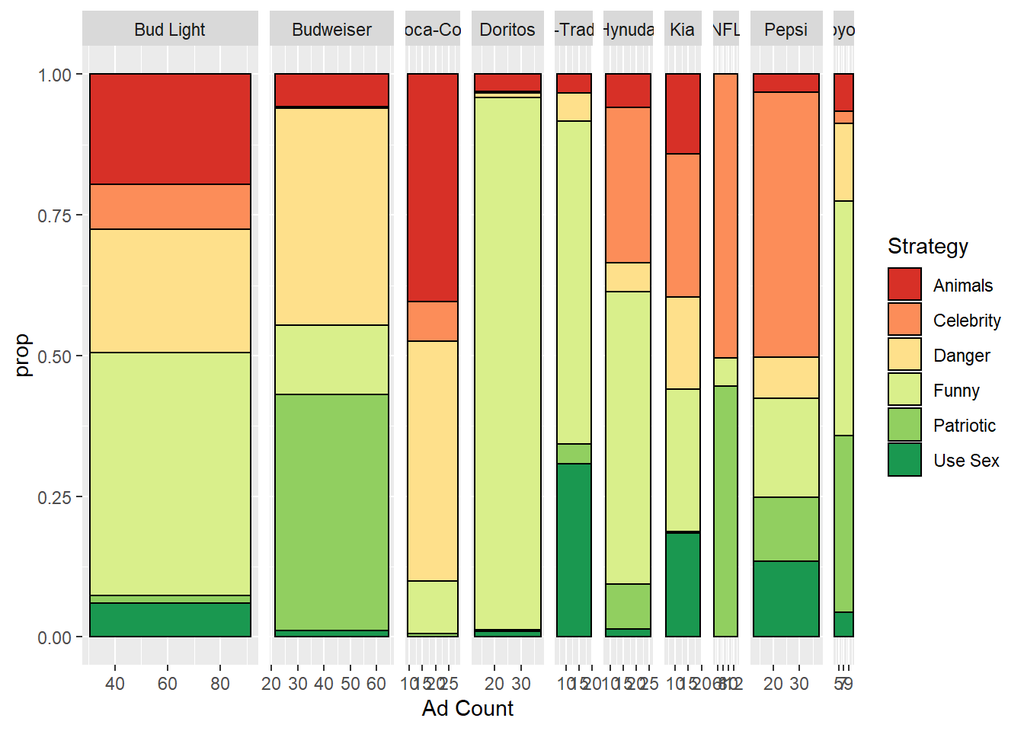

This might as well be a stacked bar chart - taking away the info provided by the width. Maybe try a heatmap.

```
## [1] "Heatmap By Year"
```

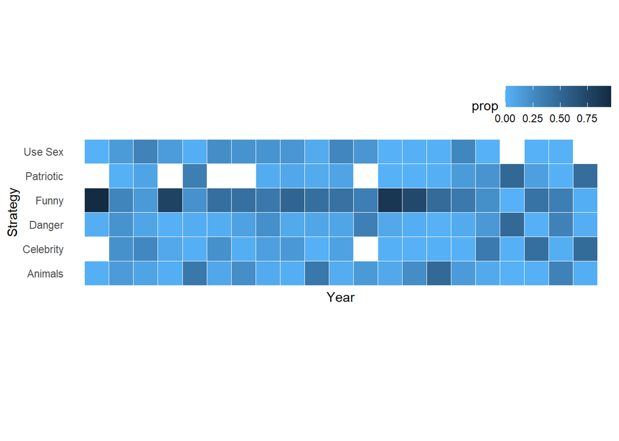

```
## [1] "Heatmap By Brand"
```

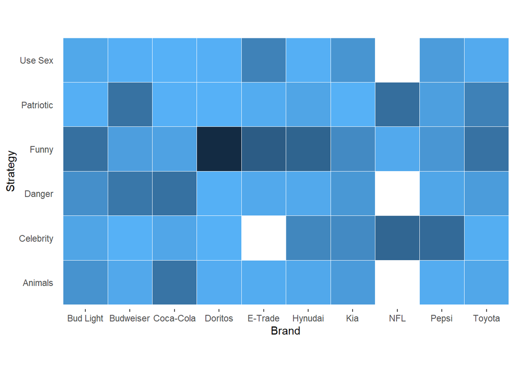

Maybe that is not too interesting though, try looking out youtube view counts relating to combinations of strategies…

```r
youtube <- readr::read_csv('youtube.csv')
```

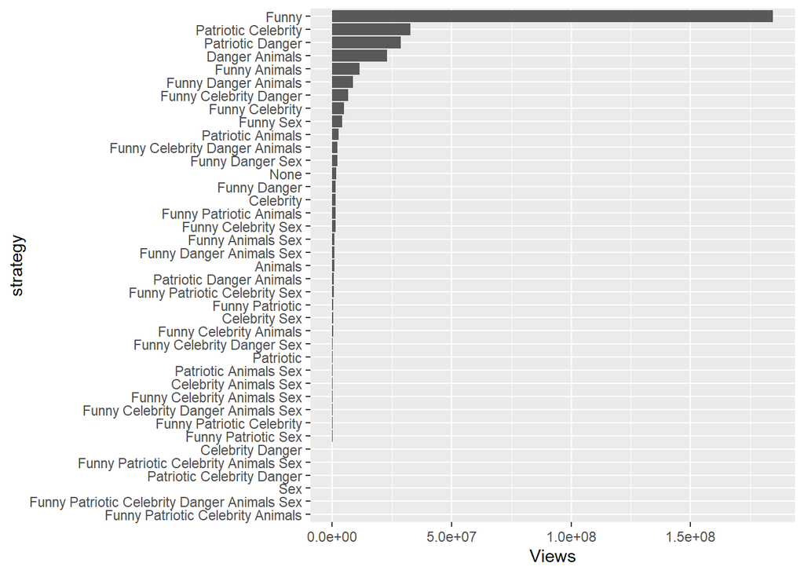

```r
youtube$view_count <- youtube$view_count %>% replace_na(0)

youtube$strategy <- paste(
  if_else(youtube$funny==TRUE, "Funny", ""),
  if_else(youtube$patriotic==TRUE, "Patriotic", ""),
  if_else(youtube$celebrity==TRUE, "Celebrity", ""),
  if_else(youtube$danger==TRUE, "Danger", ""),
  if_else(youtube$animals==TRUE, "Animals", ""),
  if_else(youtube$use_sex==TRUE, "Sex", ""), sep=" ")

youtube$strategy <- youtube$strategy %>% str_squish()

youtube$strategy <- if_else(youtube$strategy=="", "None", youtube$strategy)

youtube <- youtube %>% select(year,brand,strategy, view_count) %>% arrange(desc(view_count))

youtubeHeat <- youtube %>% group_by(year, strategy) %>% summarize(Views = sum(view_count)) %>% mutate(view_count = sum(Views), percentViews = Views /sum(Views))
youtubeSort <- youtube %>% group_by(strategy) %>% summarize(Views = sum(view_count)) %>% mutate(view_count = sum(Views), percentViews = Views /sum(Views))
youtubeSort$strategy <- factor(youtubeSort$strategy, levels = youtubeSort$strategy[order(youtubeSort$Views)])

youtubeSort %>% ggplot(aes(strategy, Views)) +                                    # Decreasingly ordered barchart
    geom_bar(stat = "identity") + coord_flip()
```

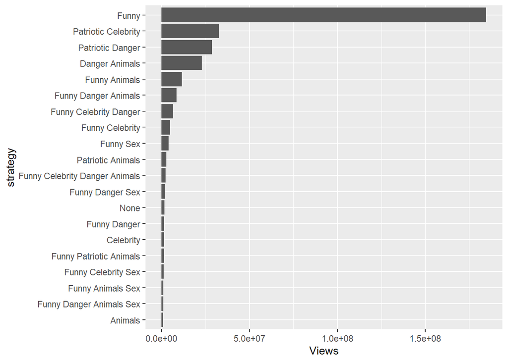

```r
youtubeSort %>% filter(Views > 750000) %>% ggplot(aes(strategy, Views)) +                                    # Decreasingly ordered barchart
    geom_bar(stat = "identity") + coord_flip()
```

How about bringing in the likes and dislikes in addition to the total views…

```r
youtube <- readr::read_csv('youtube.csv')
youtube$view_count <- youtube$view_count %>% replace_na(0)

youtube$strategy <- paste(
  if_else(youtube$funny==TRUE, "Funny", ""),
  if_else(youtube$patriotic==TRUE, "Patriotic", ""),
  if_else(youtube$celebrity==TRUE, "Celebrity", ""),
  if_else(youtube$danger==TRUE, "Danger", ""),
  if_else(youtube$animals==TRUE, "Animals", ""),
  if_else(youtube$use_sex==TRUE, "Sex", ""), sep=" ")

youtube$strategy <- youtube$strategy %>% str_squish()

youtube$strategy <- if_else(youtube$strategy=="", "None", youtube$strategy)

youtube <- youtube <- youtube %>% select(year,brand,strategy, view_count, like_count, dislike_count,comment_count) %>% arrange(desc(view_count))

youtube$dislike_count <- youtube$dislike_count * -1

tmp <- youtube %>% group_by(strategy) %>% summarize(Views = sum(view_count), Likes = sum(like_count), Dislike = sum(dislike_count), Comment = sum(comment_count)) %>% pivot_longer(Views:Comment, names_to = "stat", values_to = "Count")
```

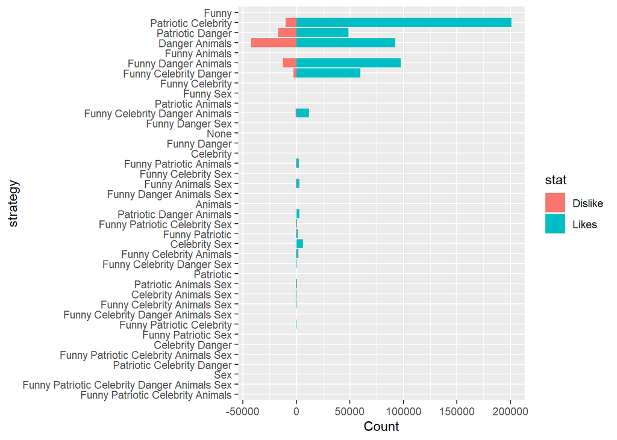

```r
tmp$Count <- tmp$Count %>% replace_na(0)

#tmp$strategy <- factor(tmp$strategy, levels = tmp$strategy[order(tmp$Views)])

tmp$strategy <- factor(tmp$strategy, levels = tmp[tmp$stat=="Views",]$strategy[order(tmp[tmp$stat=="Views",]$Count)])

tmp %>% ggplot(aes(x=strategy, y=Count, fill=stat)) +
  geom_bar(data = subset(tmp, stat=="Likes"), stat="identity") +
  geom_bar(data = subset(tmp, stat=="Dislike"), stat="identity") +
  coord_flip()
```

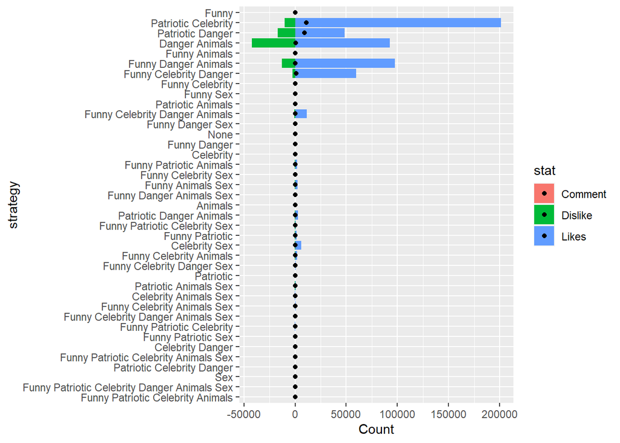

```r
tmp %>% ggplot(aes(x=strategy, y=Count, fill=stat)) +
    geom_bar(data = subset(tmp, stat=="Likes"), stat="identity") +
    geom_bar(data = subset(tmp, stat=="Dislike"), stat="identity") + geom_point(data = subset(tmp, stat=="Comment")) +
    coord_flip()
```

```r
youtube <- readr::read_csv('youtube.csv')

youtube$view_count <- youtube$view_count %>% replace_na(0)

youtube$strategy <- paste(
  if_else(youtube$funny==TRUE, "Funny", ""),
  if_else(youtube$patriotic==TRUE, "Patriotic", ""),
  if_else(youtube$celebrity==TRUE, "Celebrity", ""),
  if_else(youtube$danger==TRUE, "Danger", ""),
  if_else(youtube$animals==TRUE, "Animals", ""),
  if_else(youtube$use_sex==TRUE, "Sex", ""), sep=" ")

youtube$strategy <- youtube$strategy %>% str_squish()

youtube$strategy <- if_else(youtube$strategy=="", "None", youtube$strategy)


sub <- youtube %>% drop_na() %>% group_by(year, brand, strategy) %>% summarize(Views = sum(view_count))



sub_long <- youtube %>% mutate(funny = if_else(funny==TRUE,1,0)) %>% mutate(show_product_quickly = if_else(show_product_quickly==TRUE,1,0))%>% mutate(patriotic = if_else(patriotic==TRUE,1,0))%>% mutate(celebrity = if_else(celebrity==TRUE,1,0))%>% mutate(danger = if_else(danger==TRUE,1,0))%>% mutate(animals = if_else(animals==TRUE,1,0))%>% mutate(use_sex = if_else(use_sex==TRUE,1,0)) %>% select(year,brand, funny, show_product_quickly, patriotic, celebrity, danger, animals, use_sex)

sub_long %>% group_by(year, Strategy) %>% summarize(Count=sum(Count))

sub_long2 <- sub_long %>% group_by(year, Strategy) %>% summarize(Count=sum(Count)) %>% mutate(year.count = sum(Count), prop = Count/sum(Count))

ggplot(sub_long2,
       aes(x = year, y = prop, width = year.count, fill = Strategy)) +
    geom_bar(stat = "identity", position = "fill", colour = "black") +
    # geom_text(aes(label = scales::percent(prop)), position = position_stack(vjust = 0.5)) + # if labels are desired
    facet_grid(~year, scales = "free_x", space = "free_x") +
    scale_fill_brewer(palette = "RdYlGn") +
    # theme(panel.spacing.x = unit(0, "npc")) + # if no spacing preferred between bars
    theme_void()


sub_long2 %>% ggplot(aes(year, Strategy, fill=Count)) +
    geom_tile(color="white") + scale_x_discrete()
geom_tile(color="white") + scale_x_discrete() + coord_equal() + theme(axis.ticks.y = element_blank(),panel.background = element_blank(),legend.position = c(0.87, 1.21),legend.background = element_blank(),legend.direction = "horizontal") + scale_fill_gradient(labels = c("Never", "Always"))
```